# A3: SPL Library Checkouts

### Introduction

Victoria Schwab is an American fantasy and science fiction writer. She debuted her first novel, “The Near Witch” in 2011 and has spent the past 11 years building on this discography. She has published around 39 books, multiple short stories, and has adapted her stories into cinema. Her first TV Show “First Kill”, based on her short story by the same name, was released on Netflix in June 2022. As Victoria Schwab’s discography increases, new readers of her work need guidance on which books or series to start their Victoria Schwab journey with. This report, which examines data from Seattle Public Library, will look into the popularity of Victoria Schwabs books and series to offer a good starting point to her new audience.

Specifically, this report analyzes three important questions. The first questions is on which book series of Victoria Schwab’s was the most popular, and which month was the most popular for each series? The second question asks which medium is the most popular and how has this changed over the years? Lastly, this report will answer which of Victoria Schwab’s books is the most popular in the past year? To answer these questions, the key variables include:

- Library checkouts:
  - The amount of times a book is checked out of the library is used to quantify a particular books popularity.
- Time
  - What is the trend of checking out Victoria Schwab books or series? In this report, both year and month are used as time frames to inform on the trend of popularity of each book.
- Books
  - Which books or series hold the highest popularity? Victoria Schwab writes both stand alone novels and book series. This report looks into each book individually as well as books bundled with their series to give new audience members options of which type to begin their journey with.
- Mediums
  - Which medium is Victoria Schwabs books typically enjoyed using? This variable encompass’ physical books, eBooks, audiobooks, and soundisc’s. Understanding the medium of engaging with the book will inform a new reader on whick medium they choose to engage the books with themselves.

### Summary Information

In terms of most popular series, **Shades of Magic Series** is the series with the highest amount of checkouts, with **1960** checkouts in total. Her second most popular series is the **Villains Series** with **846** checkouts. These two series would be a good starting point for a reader looking for a series over a stand alone novel.

When it comes to the method of engaging with Victoria Schwabs works, the most used medium for people checking out her work from the library is an **ebook**. Out of the **34238** checkouts of Victoria Scwabs work, **16319** of these checkouts have been in **ebook** format. The second most common method for accessing her material is through **audiobook**, with **12314** out of the **34238** total checkouts of Victoria Schwab books checked out being **audiobook’s**. For beginners without a preference in methods for engaging in material, these two methods are seen as the preferred method for accessing her material to library goers and worth considering engaging in her discography with.

### The Dataset

This data was collected and published by the Seattle Public Library. There are twelve parameters of the data; if the item is physical or digital (UsageClass), if the item was checked out online or in-person (CheckoutType), the type of item (MaterialType), the year the item was checked out (CheckoutYear), the month the item was checked out (CheckoutMonth), the amount of checkouts for an item (Checkouts), the item title(Title), the items ISBN number (ISBN), the author (Creator), the genre or subject of the item (Subjects), the items publisher (Publisher), and the year of publication (PublicationYear).

The data collection for this dataset began April 2005 and is still continuous with updates occurring monthly. This data was collected by the Seattle Public Library to make predictions for which books will be checked out each month. This helps them keep in use items on the shelf, and move the items that are not being checked out to locations where they will be used. The Open Data Program in the City of Seattle required data generated by the City of Seattle to be public, which is likely why this information is now open to the public.

When interacting with this data set, an ethical question that needs to be considered is privacy and if people consented to this information being made public. Is there any way that a checkout could be tracked to an individual? No matter how encoded a piece of data is, there is often a way that a hacker or a determined individual can determine the owner of a piece of information. Since this is the case, do people consent to their information being shared publicly, and do they know that they are consenting?

There are a few limitations to this data. One limitation is the structure of the data points. For example, authors’ names are not spelled consistently throughout the Creator column. For my specific analysis I noticed that Victoria Schwab’s name appeared in three different formats on this dataset, “Schwab, Victoria”, “Victoria Schwab”, and “V. E. Schwab’’. When working with this data, I had to filter the Creator column to three variables to create the data frame. This leaves room for an error that is challenging to catch due to the volume of data points in the database. The Creator column is not the only one that is formatted in this way, but the Title column is also written with many different variations for each book. This inconsistency in the data naming makes it extremely challenging to analyze this data. Another limitation in this dataset is that it contains the information for the entirety of Seattle’s Public Libraries without differentiating between branches. The types of analyses that can be performed on this dataset are limited to the entire Seattle area, which reduces the scope of possible analyses and understanding of Seattle’s Public Library system.

### First Trends Over Time Chart

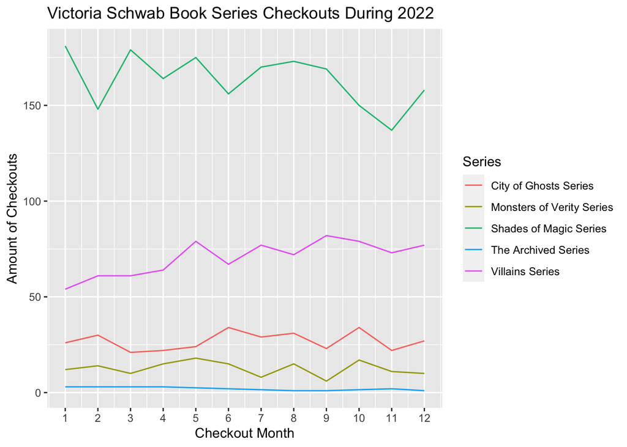

#### Chart Summary

This chart displays the trends of checkouts for each of Victoria Schwabs book series in the past year, 2022. One thing to note in this graph is that Victoria Schwab has a book series named “Everyday Angel” which is not displayed on this graph. The reason that this series is absent from the graph is that the last checkout date for any book in this series was in April 2017. This chart is important for any new comer to Victoria Scwabs discography. The graph makes a clear distinction between which series of Victoria Schwabs are the most popular. Victoria Scwab did not release any new series or books in a series during 2022, so the popularity of a series will not be affected in any particular month by their release. A pattern that arosee in this chart is that the popularity of any individual series did not change in terms of another series throughout the year. The popularity of each series during 2022 from greatest to lowest was, “Shades of Magic”, “Villans”, “City of Ghosts”, “Monsters of Verity”, and “The Archived”.

### Second Trends Over Time Chart

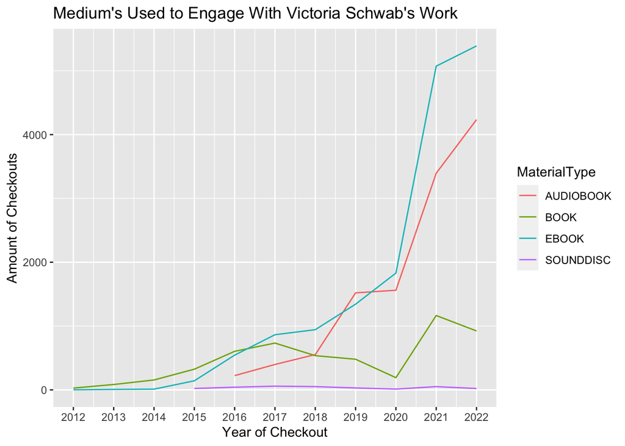

### Bar Chart

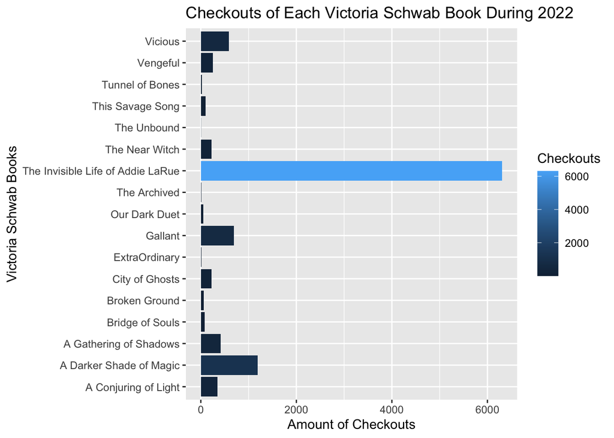

#### Chart Summary

This chart displays the amount of checkouts for each of Victoria Schwabs Books during 2022. It is important to note that the book “Gallant” was released March 1st, 2022. This release date might impact the popularity of the book in this chart. This chart is important for new commers to Victoria Schwabs work’s because it visually explains which books are the most popular. By looking at this chart, the decision of which book to begin consuming Schwabs works with should be a much simpler choice. From this chart, there is a clear preference by readers towards the book “The Invisible Life of Addie LaRue” with this book having over 6,000 checkouts in the last year. The next book that is commonly checked out is “A Darker Shade of Magic” with a little over 1,000 checkouts in the last year.